# Reproducible research assign 1

Load the activity.csv to R and process the data.

```r
options(warn=-1)
library(data.table)
dt <- fread("activity.csv")
```

Ignore the missing value from the data set and calculate the total number of steps taken per day and plot this.

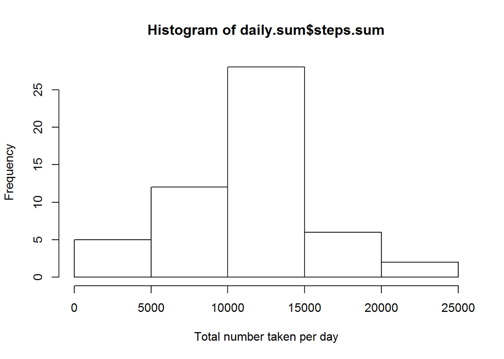

```r
# Calcuate the total number of steps taken per day
daily.sum <- dt[,.(steps.sum = sum(steps)),by=.(date)]
hist(daily.sum$steps.sum,
     xlab = "Total number taken per day")
```

```r
# Calculate mean and median steps per day by ignoring NAs
mean.steps.total.per.day <- mean(daily.sum$steps.sum,na.rm=T)
median.steps.total.per.day <- median(daily.sum$steps.sum, na.rm=T)
```

Median of the total number of steps take per day is **10765**.

Following plot will show a time series plot of the 5-minute inverval (x-axis) and the average number of steps taken, averaged across all days (y-axis)

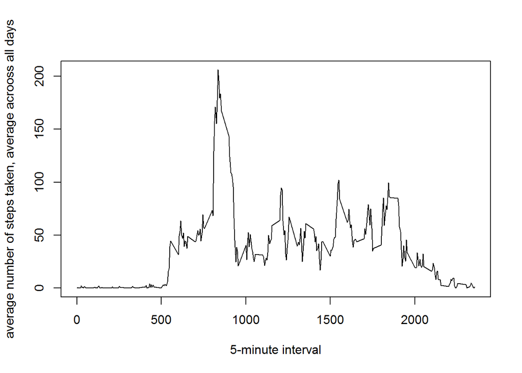

```r
# assign 0 to NA
dt[is.na(dt$steps)] <- 0

# group by interval
avg.step <- dt[,.(inter.step.avg = mean(steps)),by=.(interval)]

#
plot(inter.step.avg ~ interval, avg.step, type="l",
     xlab="5-minute interval",
     ylab="average number of steps taken, average acrooss all days")
```

```r
# Sort the inter.step.avg by descending order so the
# first item has the maximum value steps taken for that interval
sorted_avg <- avg.step[rev(order(inter.step.avg))]
```

5-minute intgerval at **835** contains the maximum number of steps taken.

```r
# Re-read in the original value to a new dataset
orgdt <- fread("activity.csv")

# Imputing missing values
tt <- orgdt[is.na(orgdt$steps)]
```

There are **2304** missing values in the dataset.

I am using mean value for the 5-minute interval to replace the missing value for that 5-minute interval. Following R code will show you how to do that.

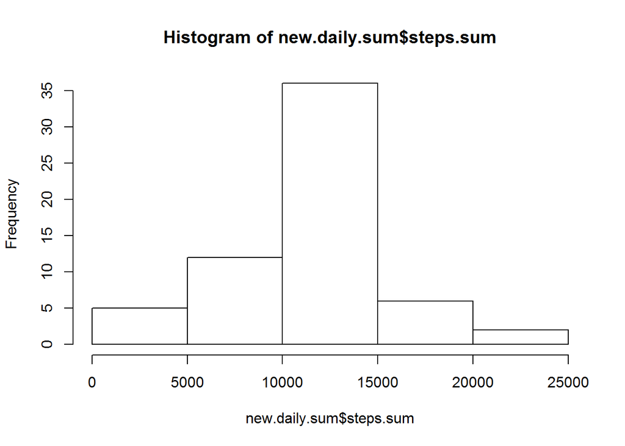

```r
# Devised a strategy
# Use the mean 5-min interval to fill in the missing data
# Get NAs from steps variable

NAs <- is.na(orgdt$steps)

# add inter.step.avg from avg.step to orgdt
orgdt$avgsteps <- avg.step$inter.step.avg
# Replace orgdt$steps with orgdt$avgsteps is orgdt$steps is NA
orgdt$steps <- as.numeric(orgdt$steps)
orgdt$steps[NAs] <- orgdt$avgsteps[NAs]

# Remove the avgsteps column
orgdt$avgsteps <- NULL

# After removing the avgsteps column, we have a dataset with no NAs
new.daily.sum <- orgdt[,.(steps.sum = sum(steps)),by=.(date)]

# Draw a histogram plot
hist(new.daily.sum$steps.sum)
```

```r
new.mean.steps.total.per.day <- mean(new.daily.sum$steps.sum)
new.median.steps.total.per.day <- median(new.daily.sum$steps.sum)
```

The mean and median values from dataset without missing values are different then the mean and median values from dataset with missing values.

If the calculation involves the missing data, the results may not tell the true story of the dataset.

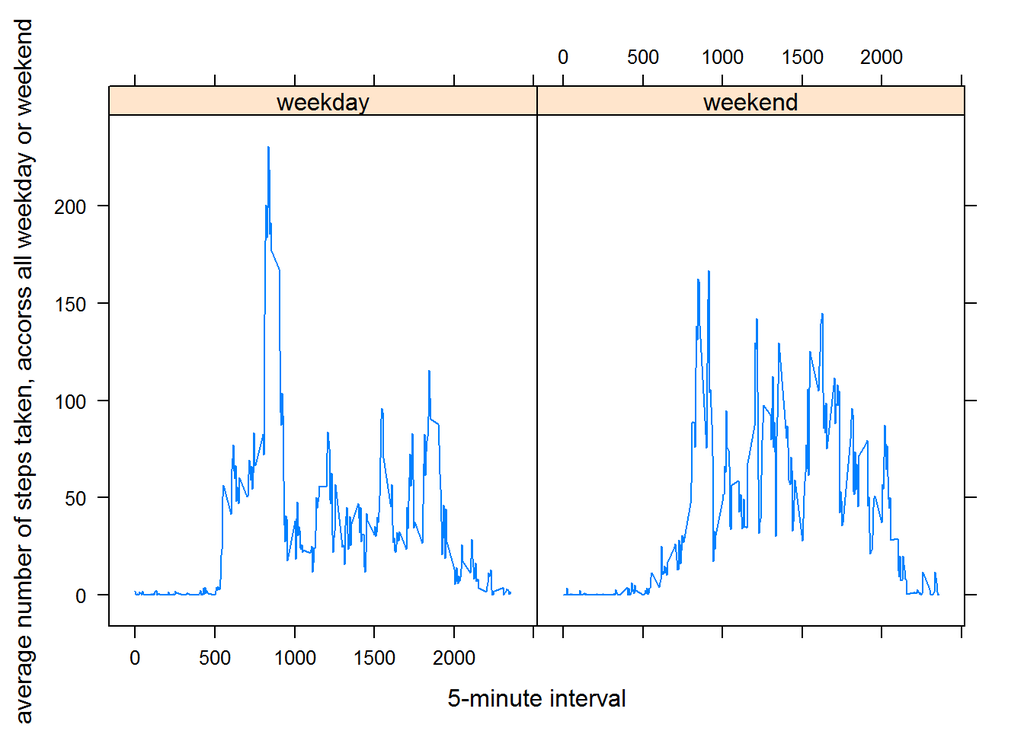

```r
# Show the difference in activity patterns between weekday and weekend
# Convert the date from character to Date format
orgdt$date <- as.Date(orgdt$date)
# Use weekdays function to convert date to Monday, Tuesday, ...
orgdt$wday <- weekdays(orgdt$date)

# If wday in "Monday", "Tuesday", "Wednesday","Thursday", or "Friday"
#  then assign "weekday" to
# Else assign "weekend"
orgdt$wday[orgdt$wday %in% c("Monday","Tuesday","Wednesday","Thursday","Friday")] <- "weekday"
orgdt$wday[orgdt$wday %in% c("Saturday","Sunday")] <- "weekend"
orgdt$wday <- as.factor(orgdt$wday)
# Load the lattice package so we can use xyplot
library(lattice)
new.avg.step <- orgdt[,.(inter.step.avg = mean(steps)),by=.(interval,wday)]
xyplot(inter.step.avg ~ interval | wday, new.avg.step,type="l",
       xlab="5-minute interval",
       ylab="average number of steps taken, accorss all weekday or weekend")
```